# notebook

Microestructura y sistemas de trading

Proyecto Final : Análisis Técnico con Regresión Simbólica | [Repositorio de Github](https://github.com/israelcastilloh/myst_equipo5_proyfinal)

> Alumna: Araceli Soledad Castillo Fuhr if708243

> Alumno: Israel Castillo Herrera if708348

> Alumno: Francisco Enriquez Muñoz if712406

> Alumna: Diana Laura Ramírez Hinojosa if706976

## Abstract

Este documento fue elaborado por Araceli Soledad Castillo Fuhr, Israel Castillo Herrera, Francisco Enriquez Muñoz y Diana Laura Ramírez Hinojosa como proyecto final para la materia de Microestructura y Sistemas de Trading - ITE1731, la cual es parte del curriculum de la licenciatura en Ingeniería Financiera, ofertada por la universidad ITESO. En el presente trabajo tiene como propósito particular establecer un sistema automatizado de trading creando un algortitmo que pueda tomar decisiones independientes a partir de un análisis estadistico y la creación de un modelo de prección a partir de regresión simbólica

0. Librerías y Dependencias

0.1 Librerías

Para correr este notebook es necesario tener instaladas y/o en el archivo requirements.txt las siguientes librerías :

- pandas>=1.1.0
- numpy>=1.19.1
- jupyter>=1.0.0
- statsmodels>=v0.12.1
- oandapyV20 >= 0.6.3
- requests >= 2.24.0
- SciPy >= 1.5.4
- gplearn==0.4.1
- scikit-learn==0.23.2
- plotly >= 4.8.2

En caso de error, instalarlas una a una en Anaconda Prompt

0.2 Dependencias

No es necesario contar con archivos de alguna carpeta.

1. Introducción

1.1 Definición de un sistema de Trading

Todo sistema de trading tiene que tener 4 componentes básicos para cumplir con las necesidades que se requieren para tomar decisiones de inversión.

1. **Criterio de datos.** En este criterio buscaremos generar un manejo de datos de forma óptima para que podamos obtener la forma que nos convega. Ya sea de días o de 4HRS, etc. Y tambien evaluaremos la forma en la que vamos a dividir los datos para posteriores etapas.
2. **Criterio de generación de señales.** La generación de señales procederá al decidir que instrumentos, momentos y que posiciones tomaremos en nuestro sistema de trading. En esto entra el conocimiento de la industria y del mercado para ser discretos en las señales.
3. **Criterio de toma de pérdidas y ganancias.** Dentro de este sector nos concentramos en ver que ratios de ganancia y pérdida elegimos. La importancia de este componente radica en que en cualquier transacción dentro del mercado existe un riesgo, y la forma en la que controlamos este riesgo para generar capital es cuestión tambien del resultado que obtenemos de nuestro sistema.
4. **Criterio de dimensionamiento de posiciones.** Finalmente queremos explorar cuanto capital por operación usaremos para nuestro sistema de trading. Esto se correlaciona a nuestras métricas de inversión como las pérdidas máximas o ganancias máximas consecutivas. Nuestro tamaño de posición es muy importante para evaluar el riesgo que nuestro sistema incurre

En este proyecto estaremos usando todos los criterios para generar un sistema de trading y obtener resultados con un backtest para ver como se hubiera nuestro sistema desempeñado en nuestr capital.

1.2 Variables con regresión simbólica

"La regresión simbólica (una aplicación de la Programación Genética) tiene el mismo objetivo de la regresión lineal pero con un espectro mucho mayor de búsqueda y muchas menos limitaciones. Dados los datos, buscará la expresión algebraica que identifique el comportamiento de estos accediendo a todo tipo de funciones y combinaciones algebraicas" (Moreno, 2007)

Para comprender el proceso de una regresión simbólica primero hay que conocer una regresión lineal multiple, que presentan las siguiente forma al pronosticar:

$$Yhat = a_1+a_2X_1+a_3X_2 ...a_nX_{n-1}$$

De esta forma, usando un modelo de regresión lineal se puede llegar a un pronóstico con un bajo error, si hay una correcta ingeniería de variables. Sin embargo, es necesario saber que una regresión de este tipo tiene una gran limitación: no puede detectar combinaciones no lineales de las variables.

Por el otro lado, uan regresión simbólica consiste en la itnegración de las mismas variables con un set de funciones dados, como por ejemplo senos, cosenos, valores absolutos, valores máximos y mínimos, divisiones, etc. Esta regresión genera una función por medio de un algoritmo genético, que use una combinación de las variables y las funciones anteriores. Un ejemplo de una función de una regresión simbólica podría ser el siguiente:

$$Yhat_{simbolico} = \cos(X_n-a_1)-sen(\frac{X_1}{max(X_2,X_3)})$$

Al ser un algoritmo genético, tiene desventajas que tienen que ver con máximos y mínimos locales(Moreno, 2007) y no hay garantía de que la ecuación encontrada sea la mejor, ya que se ven involucrados múmeros aleatorios

Es por estas razones que en este proyecto se propone la unción de estas dos regresiones. Se utilizará la regresión simbólica para generar variables no lineales, y se añadirán al modelo de una regresión simbólica, para comparar la suma de los residuales al cuadrado, y bsucar el mejor modelo posible en el alcance del proyecto

2. Objetivos

2.1 Objetivo general

Establecer un sistema automatizado de trading.

2.2 Objetivos específicos

- Tomar decisiones financieras como la seleccion de la divisa, parámetro de operaciones y administración del capital.
- Analizar los datos estadísticamente.
- Seleccionar mejor modelo de regresión.
- Realizar Backtest con el modelo seleccionado.
- Realizar métricas de atribución al desempeño con los resultados obtenidos.

3. Datos

```python
from main import *
import functions as ft
import visualizations as vs
```

```
    |   Population Average    |             Best Individual              |
---- ------------------------- ------------------------------------------ ----------
 Gen   Length          Fitness   Length          Fitness      OOB Fitness  Time Left
   0    80.16        0.0835012        3          0.45727              N/A      5.76m
```

[output not shown]

```python
# primeros 4 datos de la divisa a utilizar
datos_divisa[:4]
```

| TimeStamp | Open | High | Low | Close |
| --- | --- | --- | --- | --- |
| 2016-01-03 21:00:00+00:00 | 17.22 | 17.39 | 17.19 | 17.31 |
| 2016-01-04 21:00:00+00:00 | 17.31 | 17.38 | 17.26 | 17.33 |
| 2016-01-05 21:00:00+00:00 | 17.33 | 17.56 | 17.32 | 17.54 |
| 2016-01-06 21:00:00+00:00 | 17.54 | 17.81 | 17.51 | 17.79 |

4. Procesos

## Parte 1: Aspectos Financieros

1.1 Descarga de datos

```python
vs.general(datos_divisa) #datos históricos de la divisa diario, de 4 años
```

[interactive chart not shown]

## Parte 2: Aspectos estadísticos

2.1 Prueba de Estacionaridad

Como primer paso del anáilisis estadístico se le realizó a la serie de tiempo de la divisa una prueba de estacionaridad para conocer si la media y la varianza son constantes en el tiempo. En caso de que no lo fuera se realizarían las diferenciaciones correspondientes para que la serie sea estacionaria, cuyos rezagos resultantes nos brindarían información valiosa para las regresiones.

```python
series, lags = ft.check_stationarity(train)
print('Se necesitan', lags, 'rezagos para que esta serie sea estacionaria.')
```

```
Se necesitan 1 rezagos para que esta serie sea estacionaria.
```

El resultado obtenido es que la serie no es estacionaria, y se necesitó una diferenciación para que lo fuera. Esta información se tomaría en cuenta para las variables simbólicas.

2.2 Autocorrelación y Autocorrelación Parcial

Después se bucaron rezagos significativos en la fac y fac parcial de la serie de tiempo, estos resultados también serian importantes en la regresión simbólica.

```python
p, q = ft.f_autocorrelation(train)
print('El resultado de rezagos significativos para p y q es de', p, 'y', q, 'respectivamente.')
```

```
El resultado de rezagos significativos para p y q es de 1 y 1 respectivamente.
```

Como resultado se obtuvo que en ambas había un rezago significativo, en el valor uno para ambas.

2.3 Prueba de normalidad

También se realizó una prueba de normalidad a los datos para verificar si se distribuyen normalmente, la prueba utilizada fue shapiro-test para decidir si se rechaza o no la hipótesis nula que corresponde a que los datos son normales. Si el p-value es menor a 0.5 la hipótesis se rechaza, caso contrario se acepta.

```python
normalidad = ft.check_noramlity(train)
print('La prueba de normalidad resulta:', normalidad, ', por lo tanto los datos no son normales')
```

```
La prueba de normalidad resulta: False , por lo tanto los datos no son normales
```

En el caso de los datos utilizados en este proyecto se tuvo que rechazar la hipótesis nula por lo que se concluye que los datos no son normales.

2.4 Prueba de Estacionalidad

Para verificar si los datos se repiten cada cierto tiempo, o existe cierta estacionalidad se utilizó una prueba de periodograma, que nos muestra cada cuanto tiempo existe cierta repetición en los datos, o también puede llamarse patrón.

```python
ft.check_seasonal(train)
```

|  | power | periods |
| --- | --- | --- |
| 0 | 43.28 | 187.00 |
| 1 | 19.89 | 49.21 |
| 2 | 15.78 | 85.00 |

```python
vs.get_periodogram(train)
```

```
C:\Users\Usuario\Documents\ITESO\9no Semestre\MyST\Proyecto Final\myst_equipo5_proyfinal\visualizations.py:34: RuntimeWarning:

divide by zero encountered in true_divide
```

[interactive chart not shown]

Los resultados de esta prueba los podemos ver gráficamente en la gráfica anterior y en el dataframe. En este caso se encontró que hay cierto patrón que se repite cada 187 días, 49 días y cada 85 días. Por lo que se concluye de esta prueba que los datos son estacionales, y hay cierta periodicidad.

2.5 Detección de Atípicos

Para la detección de atípicos se utilizó una gráfica para ver la concentración de los datos de la divisa analizada en este proyecto.

```python
vs.get_atipicos(train)
```

[interactive chart not shown]

En la gráfica anterior visualizamos el resultado de esta prueba, y se concluye que no hay datos atípicos, ya que los datos se encuentran entre 17.18 y 21.96 dolares, y el dato que se muestra en rojo como "atípico" en realidad no está tan alejado de la serie.

2.6 Resultados estadísticos generales

En el siguiente DataFrame se pueden visualizar los resultados obtenidos para el análisis estadístico de manera conjunta.

```python
# Calcular los valores necesarios para el análisis estadístico
estacionaridad, autocorrelacion, normalidad, seasonal,atipicos = ft.get_statistics(train)
# Obtener DataFrame con resultados
estadisticos = ft.get_dfestadisticos(estacionaridad, autocorrelacion, normalidad, seasonal,atipicos)
estadisticos
```

|  | Estacionaridad | Autocorrelacion y Autocorrelacion parcial | Prueba de normalidad | Estacionalidad | Valores Atipicos |
| --- | --- | --- | --- | --- | --- |
| 0 | No | Existen rezagos significativos | Los datos no son normales | Sí | No |

## Parte 3: Computacionales

### Parte 3.1: Generación de variables

Para generar las variables, se utilizaron:

- Pips descontados al cierre
- Pips descontados alcistas
- Pips descontados bajistas
- Pips descontados en total (medida de volatilidad)
- Promedio móviles de 1 a 3 datos anteriores
- Rezagos de 1 a 3 datos anteriores
- Uso del producto hadamard entre el promedio movil y rezago en cada periodo
- Serie de fourier con la infoRmación con mayor relevancia del periodograma

```python
features_divisa.head(3) #Crear variables artificiales
```

| TimeStamp | predict | co | ho | ol | hl | ... | 156.00_cos | 208.00_sen | 208.00_cos | 138.67_sen | 138.67_cos |
| --- | --- | --- | --- | --- | --- | --- | --- | --- | --- | --- | --- |
| 2016-01-06 21:00:00+00:00 | 17.92 | 2483.70 | 2632.20 | 271.40 | 2903.60 | ... | 0.99 | 0.12 | 0.99 | 0.18 | 0.98 |
| 2016-01-07 21:00:00+00:00 | 17.93 | 1301.80 | 1848.70 | 813.00 | 2661.70 | ... | 0.98 | 0.15 | 0.99 | 0.22 | 0.97 |
| 2016-01-08 21:00:00+00:00 | 17.89 | 143.80 | 352.20 | 95.60 | 447.80 | ... | 0.97 | 0.18 | 0.98 | 0.27 | 0.96 |

3 rows × 39 columns

Con la información anterior, se buscó la mejor regresión usando:

- La regresión lineal múltiple
- Regresión con regularización Ridge (que busca penaliza a algunas variables)
- Regresión con regularizaciónLasso (que reduce a 0 si hay variables que no ayudan a la regresión)
- Regresión con regularización Elasticnet (que combina Ridge y Lasso)

Y se obtuvo que de los 4 modelos, el mejor fue Regresión con regularización Ridge, con una suma de residuales al cuadrado de 571.29

```python
lm_model["summary"] # Comparación rss
```

```
{'linear rss': 7951.98603225418,
 'Ridge rss': 571.2992204120014,
 'lasso rss': 649.6246858979298,
 'elasticnet rss': 649.6246858979298}
```

### Parte 3.2: Inclusión variables simbólicas

```python
nuevos_features.head(3) #Las ultimas 20 columans representan las variables simbpolicas con menor correlación
```

| TimeStamp | 0 | 1 | 2 | 3 | 4 | ... | 53 | 54 | 55 | 56 | 57 |
| --- | --- | --- | --- | --- | --- | --- | --- | --- | --- | --- | --- |
| 2016-01-06 21:00:00+00:00 | 2483.70 | 2632.20 | 271.40 | 2903.60 | 111.90 | ... | 7.99 | 7.52 | 2291.30 | 294.60 | 2465.75 |
| 2016-01-07 21:00:00+00:00 | 1301.80 | 1848.70 | 813.00 | 2661.70 | 271.40 | ... | 8.07 | 7.54 | 2632.20 | 422.80 | 2245.45 |
| 2016-01-08 21:00:00+00:00 | 143.80 | 352.20 | 95.60 | 447.80 | 813.00 | ... | 7.54 | 7.49 | 2104.07 | 322.97 | 1106.45 |

3 rows × 58 columns

```python
#agregar la variable predictora
nuevos = pd.concat([nuevos_features, features_divisa.iloc[:,0]],axis=1)
nuevos[:5]
```

| TimeStamp | 0 | 1 | 2 | 3 | 4 | ... | 54 | 55 | 56 | 57 | predict |
| --- | --- | --- | --- | --- | --- | --- | --- | --- | --- | --- | --- |
| 2016-01-06 21:00:00+00:00 | 2483.70 | 2632.20 | 271.40 | 2903.60 | 111.90 | ... | 7.52 | 2291.30 | 294.60 | 2465.75 | 17.92 |
| 2016-01-07 21:00:00+00:00 | 1301.80 | 1848.70 | 813.00 | 2661.70 | 271.40 | ... | 7.54 | 2632.20 | 422.80 | 2245.45 | 17.93 |
| 2016-01-08 21:00:00+00:00 | 143.80 | 352.20 | 95.60 | 447.80 | 813.00 | ... | 7.49 | 2104.07 | 322.97 | 1106.45 | 17.89 |
| 2016-01-10 21:00:00+00:00 | -261.00 | 1002.40 | 1352.80 | 2355.20 | 95.60 | ... | 7.29 | 2092.07 | 633.20 | 684.30 | 17.86 |
| 2016-01-11 21:00:00+00:00 | -323.40 | 829.50 | 1632.30 | 2461.80 | 1352.80 | ... | 6.92 | 1981.62 | 728.03 | 923.95 | 17.94 |

5 rows × 59 columns

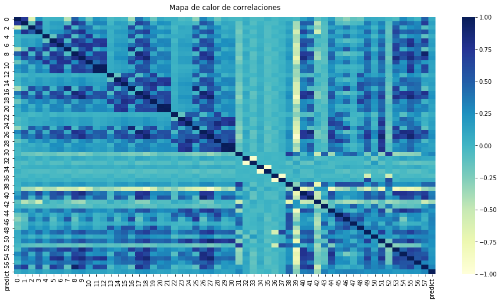

```python
vs.heatmap_corr(nuevos)
```

Con estas variables añadidas, se vuelve a buscar el mejor modelo de regresión linae y regularizaciones, obteniendo como ganador al modelo Ridge, con un rss de 500.66

```python
lm_model_s["summary"] #comparación modelos incluyendo variables simbólicas
```

```
{'linear rss': 846.6419737119938,
 'Ridge rss': 500.66872739746026,
 'lasso rss': 649.6246858979298,
 'elasticnet rss': 649.6246858979298}
```

Despues de analizar los 8 modelos, se concluye que la regularización Ridge en la regresión lineal con variables simbólicas es el mejor en el periodo de train

Para confirmar la selección de este modelo se hizo una prueba de heterodasticidad con el fin de ver si los datos para verificar que la varianza de los errores no es igual en todas las observaciones. Sin embargo, si los datos son heterocedásticos no se cumple uno de los requisitos de los modelos. Por lo que se espera que esta prueba sea negativa.

```python
hetero
```

```
False
```

La conclusión de esta prueba es que los datos no son heterocedásticos por lo que se continua con el modelo seleccionado.

## Parte 3: Backtest

```python
vs.pronostico(prediccion)
```

[interactive chart not shown]

```python
prediccion[:5]
```

| TimeStamp | predicted | real |
| --- | --- | --- |
| 2019-01-01 21:00:00+00:00 | 18.54 | 19.62 |
| 2019-01-02 21:00:00+00:00 | 18.39 | 19.42 |
| 2019-01-03 21:00:00+00:00 | 18.35 | 19.42 |
| 2019-01-04 21:00:00+00:00 | 18.32 | 19.36 |
| 2019-01-06 21:00:00+00:00 | 18.22 | 19.38 |

```python
backtest = ft.backtest(prediccion, datos_divisa)
backtest[:5]
```

[output not shown]

| TimeStamp | predicted | real | Close | Open | event | p_apertura | p_l | cap |
| --- | --- | --- | --- | --- | --- | --- | --- | --- |
| 2019-01-01 21:00:00+00:00 | 18.54 | 19.62 | 19.54 | 19.65 | sell | 19.65 | 30.16 | 100030.16 |
| 2019-01-02 21:00:00+00:00 | 18.39 | 19.42 | 19.62 | 19.54 | sell | 19.54 | 124.20 | 100154.36 |
| 2019-01-03 21:00:00+00:00 | 18.35 | 19.42 | 19.42 | 19.62 | sell | 19.62 | 197.34 | 100351.70 |
| 2019-01-04 21:00:00+00:00 | 18.32 | 19.36 | 19.42 | 19.42 | sell | 19.42 | 53.27 | 100404.97 |
| 2019-01-06 21:00:00+00:00 | 18.22 | 19.38 | 19.36 | 19.42 | sell | 19.42 | 43.68 | 100448.65 |

5. Metricas de Atribucion al desempeño

Para finalizar, se realizó un analisis a los resultados obtenidos de la simulación de trading, con métricas de atribución al desempeño como lo son el sharpe, el drawdown y el drawup. Se obtuvieron los siguientes resultados:

```python
df = ft.get_df(backtest)
mad, lista = ft.f_estadisticas_mad(df, True)
mad
```

|  | metrica | valor | descripcion |
| --- | --- | --- | --- |
| 0 | sharpe | 0.01 | Sharpe Ratio |
| 1 | drawdown_capi | [ 2019-04-11 2019-08-27 2335.7900000000227] | DrawDown de Capital |
| 2 | drawup_capi | [ 2019-08-27 2019-12-30 4072.2500000000146] | DrawUp de Capital |

```python
vs.get_chart_drawdown_drawup(True, lista, df)
```

[interactive chart not shown]

En la gráfica podemos ver visualmente como fue el drawdown y el drawup. Se puede ver que hubo un periodo de drawdown largo, sin embargo al final se recupera y comienza el drawup hasta el día final de inversión.

6. Conclusiones

6. Referencias

- Moreno, Rafael (2007) Programación genética: La regresión Simbólica en "Redalyc.org". Disponible en: https://www.redalyc.org/articulo.oa?id=265420385007